# Respuestas Tarea 1

# Tarea 1

Taller de Análisis de Datos 1 Enzo Loiza

```r
gc()
```

```
          used (Mb) gc trigger  (Mb) max used  (Mb)
Ncells 1185219 63.3    2053565 109.7  2053565 109.7
Vcells 2719150 20.8   10146329  77.5  7025327  53.6
```

```r
rm(list=ls())

# use libraries
library(tidyverse)
library(readxl)
```

## Ejercicio 1

a. Generamos en el `environment` los siguientes vectores que se piden:

```r
vector_1 <- seq(1, 5, .5)
vector_2 <- seq(1, 20, 2)
vector_3 <- replicate(10, 2023)
vector_4 <- as.numeric(cbind(replicate(5,1),replicate(5,0)))
vector_5 <- vector_1 + vector_2
```

Los mostramos a continuación:

```r
vector_1
```

```
[1] 1.0 1.5 2.0 2.5 3.0 3.5 4.0 4.5 5.0
```

```r
vector_2
```

```
 [1]  1  3  5  7  9 11 13 15 17 19
```

```r
vector_3
```

```
 [1] 2023 2023 2023 2023 2023 2023 2023 2023 2023 2023
```

```r
vector_4
```

```
 [1] 1 1 1 1 1 0 0 0 0 0
```

```r
vector_5
```

```
 [1]  2.0  4.5  7.0  9.5 12.0 14.5 17.0 19.5 22.0 20.0
```

Los vectores `vector_1` y `vector_2` tienen distinta longitud (9 y 10 respectivamente). Por lo tanto, la coerción para la suma de ambos vectores corresponde a que se suman los últimos valores del `vector_2` (el vector más largo) con los primeros del `vector_1` (el vector más corto), y el vector final quedará con la longitud del más largo. En este caso específico, el `vector_5` tendrá longitud 10.

Explicamos la diferencia entre los vectores, matrices y dataframes: - `Vector`: es una colección de datos que pueden ser sólo de un mismo tipo. Su única dimensión es el largo. Los números son en sí vectores de largo 1. Ejemplos:  
`v <- 1`  
`a <- c(1,2)`  
`b <- seq(1,10)`

- `Matrix`: las matrices son colecciones de vectores, estructuras de dos dimensiones que contienen vectores, todos del mismo largo. Además del largo, tienen ancho, pues se ordenan de manera matricial con las mismas características de las matrices algebraicas. Ejemplos:  
  `B <- matrix(1:9)`  
  `A <- matrix(1:12, nrow = 5, ncol = 4)`
- `DataFrame`: las dataframes son estructuras de dos dimensiones donde cada vector puede contener un tipo distinto de dato. Son versiones más flexibles de las matrices.
2. Generamos la matriz que se nos solicita, usando los vectores de la parte a, y la mostramos:

```r
M <- cbind(vector_1,
          vector_2,
          vector_3,
          vector_4,
          vector_5)
M
```

```
      vector_1 vector_2 vector_3 vector_4 vector_5
 [1,]      1.0        1     2023        1      2.0
 [2,]      1.5        3     2023        1      4.5
 [3,]      2.0        5     2023        1      7.0
 [4,]      2.5        7     2023        1      9.5
 [5,]      3.0        9     2023        1     12.0
 [6,]      3.5       11     2023        0     14.5
 [7,]      4.0       13     2023        0     17.0
 [8,]      4.5       15     2023        0     19.5
 [9,]      5.0       17     2023        0     22.0
[10,]      1.0       19     2023        0     20.0
```

El `vector_1` tiene un largo menor a los demás vectores, por lo tanto, la coerción que se aplica a este vector corresponde a: 1. establecer el largo de la matriz como el largo mayor de los vectores, y 2. reciclar los valores de los vectores con largo menor. Esto nos importa para entender qué pasa al trabajar con los datos.

La diferencia está en el tipo de datos que queremos manejar. Si necesitamos trabajar únicamente con datos numéricos, como al hacer una regresión lineal, una matriz es suficiente. Sin embargo, si queremos ver diferencias entre variables tratando los datos y creando variables binarias, necesitaremos trabajar con dataframes.

c. Primero extraemos la base de datos para trabajarla

```r
simce <- read.csv("simce2m2016_extracto.csv", sep = ',', dec = '.')
names(simce)
```

```
[1] "idalumno"        "gen_alu"         "ptje_mate2m_alu" "ptje_lect2m_alu"
[5] "cpad_p08"        "cod_depe2"
```

Los datos de simce que nos interesan para hacer la evaluación son `ptje_lect2m_alu` (puntaje lenguage) y `ptje_mate2m_alu` (puntaje matemáticas), por lo que usaremos estas variables para hacer la regresión.

```r
regresion <- lm(ptje_mate2m_alu ~ ptje_lect2m_alu,
                data = simce,
                na.rm = TRUE)
regresion
```

```
Call:
lm(formula = ptje_mate2m_alu ~ ptje_lect2m_alu, data = simce,
    na.rm = TRUE)

Coefficients:
    (Intercept)  ptje_lect2m_alu
        78.9131           0.7581
```

```r
summary(regresion)
```

```
Call:
lm(formula = ptje_mate2m_alu ~ ptje_lect2m_alu, data = simce,
    na.rm = TRUE)

Residuals:
     Min       1Q   Median       3Q      Max
-255.973  -35.029    0.472   35.174  241.423

Coefficients:
                 Estimate Std. Error t value Pr(>|t|)
(Intercept)     78.913080   0.628065   125.6   <2e-16 ***
ptje_lect2m_alu  0.758091   0.002464   307.7   <2e-16 ***
---
Signif. codes:  0 ‘***’ 0.001 ‘**’ 0.01 ‘*’ 0.05 ‘.’ 0.1 ‘ ’ 1

Residual standard error: 51.44 on 160177 degrees of freedom
Multiple R-squared:  0.3714,    Adjusted R-squared:  0.3714
F-statistic: 9.465e+04 on 1 and 160177 DF,  p-value: < 2.2e-16
```

Con lo que obtenemos errores bastante grandes, aunque la tendencia existe. Podemos verificar esto a través de un gráfico,

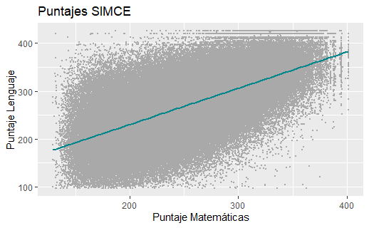

```r
ggplot(simce,
       aes(ptje_lect2m_alu,
           ptje_mate2m_alu)) +
  geom_point(size = .3,
             color = 'darkgrey')+
  geom_smooth(method='lm', color='turquoise4') +
  labs(x='Puntaje Matemáticas',
       y='Puntaje Lenguaje',
       title='Puntajes SIMCE')
```

## Pregunta 2

Primero abrimos la librería:

```r
library(WDI)
```

a. Elegimos un indicador mediante una búsqueda a través del comando `WDIsearch()`. El indicador elegido corresponde a la esperanza de vida al nacer. Este valor tiene mucha importancia tanto en salud como en seguridad social (al establecer, por ejemplo, políticas de pensión).

```r
WDIsearch("life expectancy at birth.*total")
```

|  | indicator | name |
| --- | --- | --- |
| 17308 | SP.DYN.LE00.IN | Life expectancy at birth, total (years) |

El indicador se llama `SP.DYN.LE00.IN`, pero en nuestra base de datos (`DB`) la llamaremos `leab`.

```r
DB <- WDI(country = 'all',
          indicator = c("leab"="SP.DYN.LE00.IN"),
          start = 2015,
          end = 2020,
          extra = TRUE,
          cache = NULL,
          latest = NULL,
          language = 'en') %>%
  filter(region == 'Latin America & Caribbean')
```

Vemos un pequeño resumen de la base obtenida:

```r
summary(DB)
```

```
   country             iso2c              iso3c                year
 Length:252         Length:252         Length:252         Min.   :2015
 Class :character   Class :character   Class :character   1st Qu.:2016
 Mode  :character   Mode  :character   Mode  :character   Median :2018
                                                          Mean   :2018
                                                          3rd Qu.:2019
                                                          Max.   :2020

      leab          status          lastupdated           region
 Min.   :63.24   Length:252         Length:252         Length:252
 1st Qu.:72.57   Class :character   Class :character   Class :character
 Median :74.41   Mode  :character   Mode  :character   Mode  :character
 Mean   :74.54
 3rd Qu.:77.08
 Max.   :80.61
 NA's   :9
   capital           longitude           latitude            income
 Length:252         Length:252         Length:252         Length:252
 Class :character   Class :character   Class :character   Class :character
 Mode  :character   Mode  :character   Mode  :character   Mode  :character




   lending
 Length:252
 Class :character
 Mode  :character
```

Que nos indica que tenemos 252 observaciones. Luego,

```r
DB %>% count(year) # numero de años 6
```

| year | n |
| --- | --- |
| 2015 | 42 |
| 2016 | 42 |
| 2017 | 42 |
| 2018 | 42 |
| 2019 | 42 |
| 2020 | 42 |

```r
DB %>% count(country) %>% summary() # numero de paises 42
```

```
   country                n
 Length:42          Min.   :6
 Class :character   1st Qu.:6
 Mode  :character   Median :6
                    Mean   :6
                    3rd Qu.:6
                    Max.   :6
```

Vemos que la data contiene 6 años desde 2015 hasta 2020, y 42 países.

b. Hacemos la tabla resumen de los valores de esperanza de vida por año.

```r
tabla <- DB %>%
  group_by(year) %>%
  summarise(na.rm = TRUE,
    N = sum(!is.na(leab)),
    mean = mean(leab, na.rm = TRUE),
    sd = sd(leab, na.rm = TRUE),
    min = min(leab, na.rm = TRUE),
    median = median(leab, na.rm = TRUE),
    max = max(leab, na.rm = TRUE)
  ) %>%
  left_join(DB %>% distinct(year, region), by = "year")

tabla[,c('region', 'year', 'N', 'mean', 'sd', 'min','median', 'max')]
```

| region | year | N | mean | sd | min | median | max |
| --- | --- | --- | --- | --- | --- | --- | --- |
| Latin America & Caribbean | 2015 | 41 | 74.51728 | 3.608612 | 63.237 | 74.6820 | 79.746 |
| Latin America & Caribbean | 2016 | 41 | 74.63539 | 3.530230 | 63.392 | 74.4420 | 80.270 |
| Latin America & Caribbean | 2017 | 41 | 74.58835 | 3.516664 | 63.854 | 74.7650 | 80.350 |
| Latin America & Caribbean | 2018 | 40 | 74.79784 | 3.417537 | 64.019 | 74.4680 | 80.614 |
| Latin America & Caribbean | 2019 | 40 | 74.75241 | 3.396188 | 64.255 | 74.5455 | 80.326 |
| Latin America & Caribbean | 2020 | 40 | 73.94311 | 3.669186 | 64.052 | 73.6570 | 80.149 |

La esperanza de vida se mantuvo más o menos constante hasta 2019. Sin embargo, en 2020, el indicador presentó una pequeña variación negativa. La desviación estándar, por otro lado, fue disminuyendo decimalmente los primeros 5 años, pero aumentó levemente en 2020. Estos resultados pueden deberse a la crisis sanitaria mundial producto del coronavirus.

c. Veremos si tenemos missing values. Simplemente de la tabla anterior, sabemos que existen, ahora vamos a encontrarlos:

```r
DB %>%
  filter(is.na(leab)) %>%
  select(country, year)
```

| country | year |
| --- | --- |
| Cayman Islands | 2019 |
| Cayman Islands | 2018 |
| Cayman Islands | 2020 |
| Cayman Islands | 2016 |
| Cayman Islands | 2015 |
| Cayman Islands | 2017 |
| Curacao | 2019 |
| Curacao | 2018 |
| Curacao | 2020 |

Es decir, existen missing values para las Islas Cayman (en los 6 años de análisis) y Curacao (desde 2018).

d. A nuestra base ahora le haremos un filtro para chile:

```r
chile <- DB %>% filter(country =="Chile")
```

[output not shown]

Resumimos igual que en el punto b., es decir haciendo una tabla. Esta vez incluiremos también un gráfico para mostrar de mejor forma.

```r
summary(chile$leab)
```

```
   Min. 1st Qu.  Median    Mean 3rd Qu.    Max.
  79.38   79.83   80.11   80.00   80.28   80.35
```

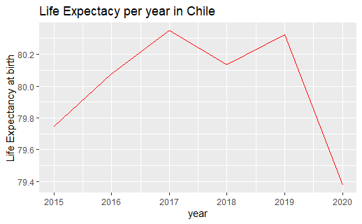

```r
ggplot(data = chile, aes(year, leab)) +
  geom_line(colour = 'red') +
  xlab('year') +
  ylab('Life Expectancy at birth') +
  ggtitle('Life Expectacy per year in Chile')
```

La esperanza de vida al nacer muestra una tendencia positiva en los años 2015-2019, sin embargo, tiene una caída brusca en 2020, posiblemente (al igual que los otros países de la región) debido a la crisis sanitaria.

## Bonus

Primero instalamos la librería necesaria

```r
library(sf)
```

Luego, cargamos el mapa de Latinoamérica:

```r
latam_shape <- ne_countries(scale = "medium",
                            type = "map_units",
                            country = "countries",
                            continent = c("South America",
                                          "North America"))
```

No creo que alcance a hacerla :(